# Crossvalidation and prediction

Peter Ralph

3 December 2019 – Advanced Biological Statistics

# Count data

## A hypothetical situation:

1. We have **counts** of transcript numbers,
2. from some individuals of different **ages** and past **exposures** to solar irradiation,
3. of two **genotypes**.

The data:

```r
data <- read.table("poisson_counts_data.tsv", header=TRUE)
```

## The model

$$\begin{aligned}
Z_i &\sim \Poisson(y_i) \\
y_i &= \exp(a_{g_i} + b \times \text{age}_i \\
&\qquad {} + c_{g_i} \times \text{exposure}_i )
\end{aligned}$$

## The result

```r
scaled_data <- with(data, list(N=length(counts),
                               counts=counts,
                               age=(age - mean(age))/sd(age),
                               expo=(exposure - mean(exposure))/sd(exposure),
                               geno=genotype))
fit1 <- stan(file="simple_poisson.stan",
             data=scaled_data,
             control=list(max_treedepth=12),
             iter=1000, chains=3)
```

## How’d we do?

Here are posterior distributions of the parameters, with **the true values in red**.

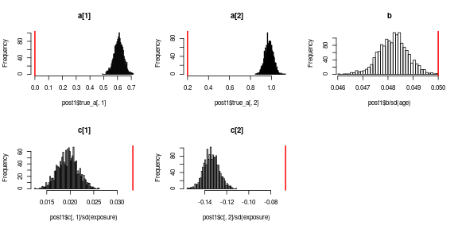

## 100 posterior predictive datasets

```r
ps <- sample(nrow(post1$a),  100)
params1 <- list(a=post1$a[ps,],
                b=post1$b[ps],
                c=post1$c[ps,])
mu1 <- with(list2env(scaled_data),
            sapply(1:100, function (k)
                exp(params1$a[k,geno]
                    + params1$b[k] * age
                    + params1$c[k,geno] * expo)))
# 100 datasets:
sim1 <- matrix(rpois(length(mu1), mu1), nrow(mu1))
```

```
model {
    vector[N] mu;
    mu = exp(a[geno]
             + b * age
             + c[geno]
               .* expo);
    counts ~ poisson(mu);
```

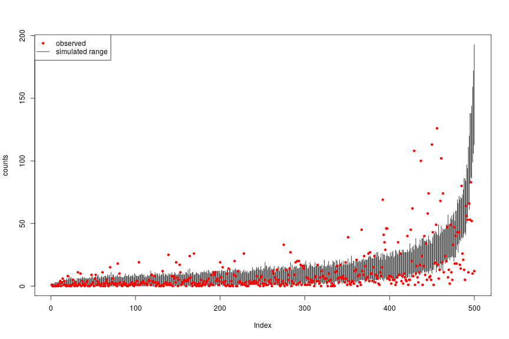

## True data are *overdispersed* relative to Poisson

Recall that if $X \sim \Poisson(\lambda)$ then
$$\E[X] = \var[X] = \lambda,$$
and so a “$z$-score” is
$$\begin{aligned}
\E\left(\frac{X - \lambda}{\sqrt{\lambda}}\right) = 0,
\qquad \qquad
\text{SD}\left(\frac{X - \lambda}{\sqrt{\lambda}}\right) = 1.
\end{aligned}$$

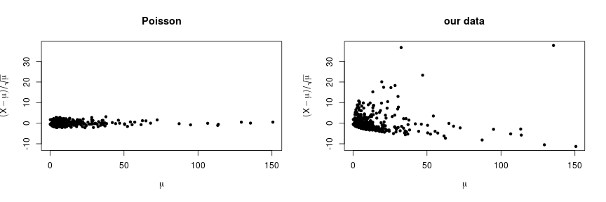

## Add overdispersion

$$\begin{aligned}
Z_i &\sim \Poisson(\mu_i) \\
\mu_i &\sim \log\Normal(y_i, \sigma) \\
y_i &= a_{g_i} + b \times \text{age}_i \\
&\qquad {} + c_{g_i} \times \text{exposure}_i
\end{aligned}$$

```
overdispersed_model <- stan_model(model_code="
data {
    int N; // number of data points
    vector[N] age;
    vector[N] exposure;
    int counts[N];
    int genotype[N];
    int ngenotypes;
}
parameters {
    vector[ngenotypes] a; // intercepts
    real b; // slope for age
    vector[ngenotypes] c; // slopes for exposure
    real<lower=0> sigma; // SD on lognormal
    vector[N] mu; // mean of the poissons
}
model {
    vector[N] y; // mean of the lognormals
    y = a[genotype] + b * age + c[genotype] .* exposure;
    mu ~ lognormal(y, sigma);
    counts ~ poisson(mu);
    a ~ normal(0, 100);
    b ~ normal(0, 10);
    c ~ normal(0, 20);
    sigma ~ normal(0, 10);
}")
```

```r
model2 <- stan_model("lognormal_poisson.stan")
fit2 <- sampling(model2,
                 data=scaled_data,
                 iter=1000, chains=3)
post2 <- rstan::extract(fit2)
```

## How’d we do *now*?

Here are posterior distributions from the full model, with the true values in red.

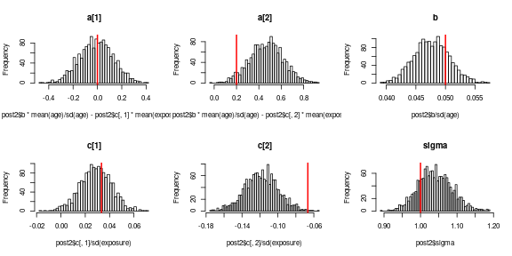

## Posterior predictive simulations, again

```r
# 100 datasets:
params2 <- list(a=colMeans(post2$a),
                b=mean(post2$b),
                c=colMeans(post2$c),
                sigma=mean(post2$sigma))
y2 <- with(list2env(scaled_data),
                params2$a[geno]
                    + params2$b * age
                    + params2$c[geno] * expo)
sim2 <- replicate(100, {
           mu = exp(rnorm(length(y2),
                          mean=y2,
                          sd=params2$sigma))
           rpois(length(mu), mu)
         })
```

```
model {
    vector[N] y;
    y = a[geno] + b * age + c[geno] .* expo;
    mu ~ lognormal(y, sigma);
    counts ~ poisson(mu);
}
```

## Now we cover the true data

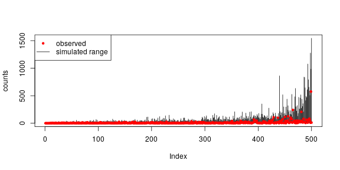

```r
ord <- order(rowMeans(mu1))
plot(rowMeans(sim2), ylab="counts", ylim=range(sim2), type='n')
segments(x0=seq_len(nrow(data)),
         y0=rowMins(sim2)[ord],
         y1=rowMaxs(sim2)[ord])
points(data$counts[ord], pch=20, col='red')
legend("topleft", pch=c(20,NA), lty=c(NA,1), legend=c("observed", "simulated range"), col=c('red', 'black'))
```

## Now we cover the true data

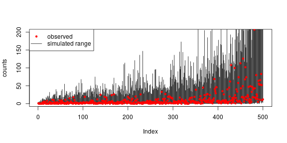

```r
plot(rowMeans(sim2), ylab="counts", ylim=c(0,200), type='n')
segments(x0=seq_len(nrow(data)),
         y0=rowMins(sim2)[ord],
         y1=rowMaxs(sim2)[ord])
points(data$counts[ord], pch=20, col='red')
legend("topleft", pch=c(20,NA), lty=c(NA,1), legend=c("observed", "simulated range"), col=c('red', 'black'))
```

## Exercise:

Explain the model, *in words*.

$$\begin{aligned}
Z_i &\sim \Poisson(\mu_i) \\
\mu_i &\sim \log\Normal(y_i, \sigma) \\
y_i &= a_{g_i} + b \times \text{age}_i \\
&\qquad {} + c_{g_i} \times \text{exposure}_i
\end{aligned}$$

```
overdispersed_model <- stan_model(model_code="
data {
    int N; // number of data points
    vector[N] age;
    vector[N] exposure;
    int counts[N];
    int genotype[N];
    int ngenotypes;
}
parameters {
    vector[ngenotypes] a; // intercepts
    real b; // slope for age
    vector[ngenotypes] c; // slopes for exposure
    real<lower=0> sigma; // SD on lognormal
    vector[N] mu; // mean of the poissons
}
model {
    vector[N] y; // mean of the lognormals
    y = a[genotype] + b * age + c[genotype] .* exposure;
    mu ~ lognormal(y, sigma);
    counts ~ poisson(mu);
    a ~ normal(0, 100);
    b ~ normal(0, 10);
    c ~ normal(0, 20);
    sigma ~ normal(0, 10);
}")
```

## Exercise 2:

Compare the result of fitting a *quasipoisson* GLM to the data.

# Prediction

[figure not shown]

is it Christmas? No. (99.73% accurate)

https://xkcd.com/2236/

## Out-of-sample prediction

To test predictive ability (and diagnose overfitting!):

1. Split the data into *test* and *training* pieces.
2. Fit the model using the training data.
3. See how well it predicts the test data.

If you do this a lot of times, it’s called *crossvalidation*.

## Prediction in Stan

```r
pred_model <- stan_model(model_code="
data {
    int N;  // number of data points
    int Nm; // number of missing counts
    vector[N] age;
    vector[N] exposure;
    int missings[Nm]; // indexes of missings
    int not_missings[N - Nm]; // the complement
    int counts[N - Nm];
    int genotype[N];
    int ngenotypes;
}
parameters {
    vector[ngenotypes] a; // intercepts
    real b; // slope for age
    vector[ngenotypes] c; // slopes for exposure
    real<lower=0> sigma; // SD on lognormal
    vector<lower=0>[N] mu; // mean of the poissons
}
model {
    vector[N] y; // mean of the lognormals
    y = a[genotype] + b * age + c[genotype] .* exposure;
    mu ~ lognormal(y, sigma);
    counts ~ poisson(mu[not_missings]);
    a ~ normal(0, 100);
    b ~ normal(0, 10);
    c ~ normal(0, 20);
    sigma ~ normal(0, 10);
}
generated quantities {
    int missing_counts[Nm];
    missing_counts = poisson_rng(mu[missings]);
}
")
```

```r
predict_these <- sample(length(data$counts), 20)

pred_data <- with(data,
      list(N=length(counts),
           Nm=length(predict_these),
           age=(age - mean(age))/sd(age),
           exposure=(exposure - mean(exposure))/sd(exposure),
           counts=counts[-predict_these],
           missings=predict_these,
           not_missings=seq_along(counts)[-predict_these],
           genotype=genotype,
           ngenotypes=length(unique(genotype))))

fit3 <- sampling(pred_model,
                 data=pred_data,
                 control=list(max_treedepth=12),
                 iter=1000, chains=3)
```

## Posterior predictive samples

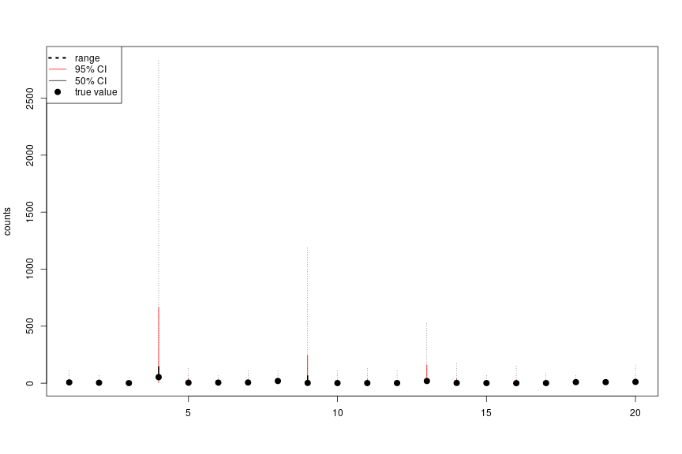

## Posterior predictive samples

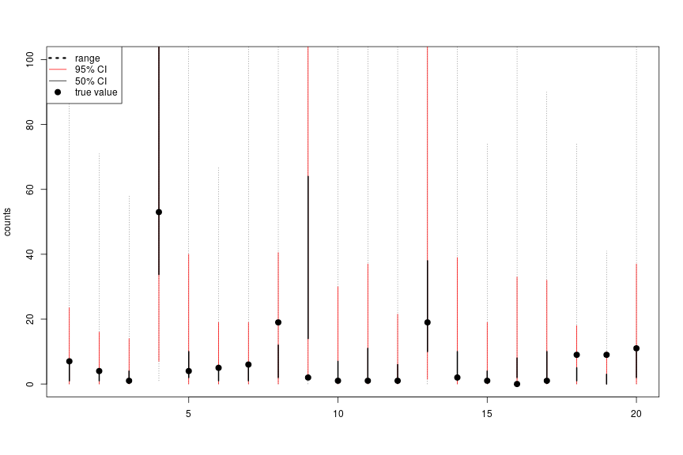

# Application: parasite counts

## The data

Tavalire et al 2016, **Genotypic variation in host response to infection affects parasite reproductive rate**, *International Journal for Parasitology*, has:

- Strain: inbred line ID
- Inf_Dose: number of parasites exposed to: 0 (control), 1, and 10
- Tray: housing for each individual
- Infected: whether or not was infected
- Initial_Size_mm: initial size of the snail
- Weeks_to_first_shed: time until the snail first produced parasites
- Total_weeks_shed: number of weeks that parasites were produced; right censored at 30
- Total_Parasites: number of parasites produced in the first 30 weeks
- Avg_Parasites_per_Shed: Total parasites/weeks shed
- Week_Died: Survival time, right censored at 30 weeks

## A question

How much do genotype and parasite dose affect parasite production?

Here’s the data

```r
head(snails <- read.csv("../Datasets/Snail_Parasite_Data/Tavalire_et_al_2016_snail_parasite_data.csv"))
```

```
##   Snail_ID Strain Inf_Dose Tray Infected Initial_Size_mm Weeks_to_first_shed Total_weeks_shed Total_Parasites Avg_Parasites_per_Shed Week_Died
## 1       60     36        0    k        0            6.67                  NA               NA              NA                     NA         2
## 2       51     36        0    o        0            5.44                  NA               NA              NA                     NA         3
## 3      431     36        0    g        0            4.89                  NA               NA              NA                     NA         3
## 4      432     36        0    e        0            3.97                  NA               NA              NA                     NA         3
## 5       56     36        0    h        0            7.97                  NA               NA              NA                     NA         6
## 6       49     36        0    c        0            7.86                  NA               NA              NA                     NA        10
```

## in class

```
mod1 <- glm(Total_Parasites ~ Strain * Total_weeks_shed + Strain : dose, data=snails, family=poisson("log"))
summary(mod1)

# mean predicted load at 0 weeks for default strain:
exp(9.6)

# default strain is the first one
levels(snails$Strain)

# predicted load of second strain relative to first one
exp(-.66)

# plot data and predicted means
plot(Total_Parasites ~ Total_weeks_shed, data=snails, col=Strain, pch=20)
newdata <- expand.grid(Strain=levels(snails$Strain), Total_weeks_shed=0:30, dose=TRUE)
for (st in levels(snails$Strain)) {
  lines(0:30, exp(preds[newdata$Strain == st]), col=match(st, levels(snails$Strain)))
}
```

## hm, intercept doesn’t look great: try some other models?

This one fails to fit because of negative values

```
> mod2 <- glm(Total_Parasites ~ Strain * Total_weeks_shed + Strain : dose, data=snails, family=poisson("identity"))
Error: no valid set of coefficients has been found: please supply starting values
In addition: Warning message:
In log(y/mu) : NaNs produced
```

Using Stan doesn’t help:

[output not shown]

## some other models

```
mod3 <- glm(Total_Parasites ~ 0 + Strain : Total_weeks_shed + Strain : dose, data=snails, family=poisson("identity"))
mod4 <- glm(Total_Parasites ~ 0 + Strain : Total_weeks_shed + Strain : dose, data=snails, family=poisson("log"))
preds3 <- predict(mod3, newdata=newdata)
preds4 <- predict(mod4, newdata=newdata)
plot(Total_Parasites ~ Total_weeks_shed, data=snails, col=Strain, pch=20)
for (st in levels(snails$Strain)) {
    lines(0:30, exp(preds[newdata$Strain == st]), col=match(st, levels(snails$Strain)))
    lines(0:30, exp(preds3[newdata$Strain == st]), col=match(st, levels(snails$Strain)), lty=3)
    lines(0:30, exp(preds4[newdata$Strain == st]), col=match(st, levels(snails$Strain)), lty=4)
}
```

## conclusions:

- poor model fit
- try a different link function (sqrt?)
- perhaps adding overdispersion? need to look at noise in more detail.

# Review

## Concepts

- statistic versus parameter
- quantifying uncertainty
- experiment vs observation
- controls
- statistical power/sensitivity
- tidy data
- Markov chain Monte Carlo
- permutation test
- multiple comparisons
- shrinkage and sharing power
- probability models
- simulation
- $p$-values
- hypothesis testing
- confidence and credible intervals
- linear models
- random effects
- prior, likelihood, and posterior
- goodness-of-fit

**Distributions:**

- Central Limit Theorem
- Gaussian/Normal
- Student’s $t$
- Binomial
- Beta
- Beta-Binomial
- Exponential
- Cauchy
- Poisson

**Visualization:**

- center, spread, outliers
- histograms
- scatter plots
- boxplots
- maximize information per unit of ink

**Statistical models:**

- ANOVA, partition of variance
- least-squares fitting $\sim$ Gaussian
- Beta-Binomial
- logistic regression
- robust regression
- General Linear (Mixed) Models